# Intro to DS - Linear Model Part I

GWU Intro to Data Science DATS 6101

2022-10-20

# HW 7: Linear models - Quantitative Regressors

This homework uses a bikeshare dataset called `BikeShare` on api.regression.fit, or `bikedata.csv` on our class GitHub repo.

### Question 1

**Import the data and name it `bikeorig`. Remove `Date`, `Casual_Users`, and `Registered_Users` from the dataset and save it as a new data frame named `bike`. How many variables are in `bike`? How many of them are imported as `int`? Feel free to rename longer variable names into shorter ones for convenience.**

```r
bikeorig = data.frame(read.csv("bikedata.csv"))
bike = subset(bikeorig, select = -c(Casual.Users, Registered.Users, Date))
# bike
```

There are 11 variables in ‘bike’.

```r
table(unlist(sapply(bike, is.integer)))
```

```
##
## FALSE  TRUE
##     2     9
```

From above we can see that there are 9 variables with ‘int’ data type.

### Question 2

**Select the subset with `Hour` equal 16 only and name the new data frame `bike16`. These are the afternoon rush hour data. How many observations are there?**

```r
bike16 = subset(bike, Hour == 16)
# bike16
```

There are 730 observations in new dataframe.

### Question 3

**Before building any models, we should make sure the variables are set up properly. Which ones should be recorded as categorical? Convert them now before proceeding to the model building.**

We will go ahead and answer this question for you…

```r
bike_final = bike16
bike_final$Season = factor(bike16$Season)
bike_final$Holiday = factor(bike16$Holiday)
bike_final$Day = factor(bike16$Day)
bike_final$Workday = factor(bike16$Working.Day)
bike_final$Weather = factor(bike16$Weather)
str(bike_final)
```

```
## 'data.frame':    730 obs. of  14 variables:
##  $ Season             : Factor w/ 4 levels "1","2","3","4": 4 4 4 4 4 4 4 4 4 4 ...
##  $ Hour               : int  16 16 16 16 16 16 16 16 16 16 ...
##  $ Holiday            : Factor w/ 2 levels "0","1": 1 1 1 1 1 1 1 1 1 1 ...
##  $ Day.of.the.Week    : int  6 0 1 2 3 4 5 6 0 1 ...
##  $ Working.Day        : int  0 0 1 1 1 1 1 0 0 1 ...
##  $ Weather.Type       : int  2 3 1 1 1 1 2 1 1 1 ...
##  $ Temperature.F      : num  52.1 45.2 38.3 41.8 41.8 38.3 33.1 31.4 33.1 33.1 ...
##  $ Temperature.Feels.F: num  53.6 42.8 32 37.4 41 33.8 28.4 19.4 23 28.4 ...
##  $ Humidity           : int  82 71 30 49 28 38 37 29 34 40 ...
##  $ Wind.Speed         : int  20 11 17 17 6 11 11 30 30 9 ...
##  $ Total.Users        : int  93 76 76 83 89 86 87 76 92 74 ...
##  $ Day                : Factor w/ 7 levels "0","1","2","3",..: 7 1 2 3 4 5 6 7 1 2 ...
##  $ Workday            : Factor w/ 2 levels "0","1": 1 1 2 2 2 2 2 1 1 2 ...
##  $ Weather            : Factor w/ 4 levels "1","2","3","4": 2 3 1 1 1 1 2 1 1 1 ...
```

The above code converts the following variables into categorical (factor):  
`Season`, `Holiday`, `Day`, `Workday`, and `Weather`. Notice that the data frame `bike16` still has all variables numerical, while the data frame `bike_final` has the categorical columns that we just converted.

### Question 4

**Make a `pairs()` plot with all the variables (quantitative and qualitative) in the `bike_final` dataset.**

Note: While the `cor()` function does not accept categorical variables (and therefore we cannot use it for `corrplot()`), the `lattice::pairs()` function does not complain about categorical columns. We can still use it to get a visual distribution of data values from it.

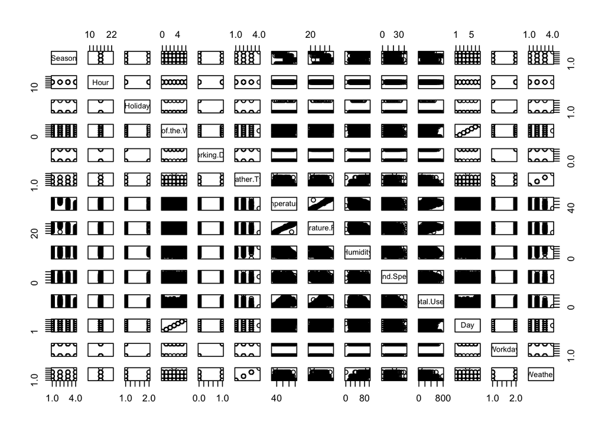

```r
pairs(bike_final)
```

### Question 5

**Make a `corrplot()` with only the numerical variables in the `bike_final` dataset.**

Note: correlation functions will not work with categorical/factor variables. You can either subset the data frame to only numerical variables first, then create the correlation matrix to plot. Or you can create the correlation matrix from `bike16`, then select out the portion of the matrix that you want. Use options that does a good job showing the relationships between different variables.

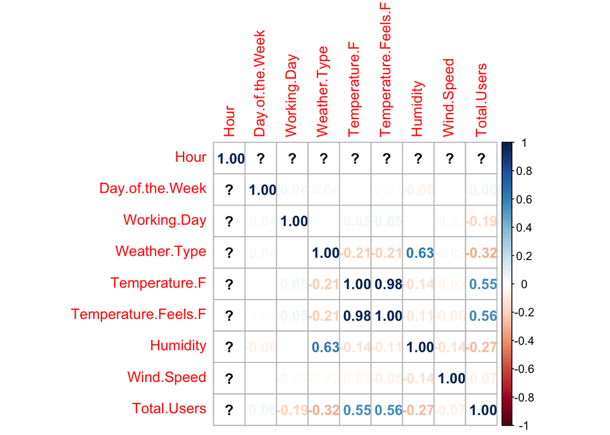

```r
# bike_cor = cor(bike_final, method = 'pearson')
bike_cor = cor(bike_final[sapply(bike_final,is.numeric)])
corrplot::corrplot(bike_cor, method = 'number')
```

### Question 6

**Using ony the numerical variables from the `bike_final` dataset, build a linear model with 1 independent variable to predict the `Total Users`. Choose the variable with the strongest correlation coefficient. Comment on the coefficient values, their p-values, and the multiple R-squared value.**

```r
# colnames(bike_final)[which(colnames(bike_final) == 'Temparature.Feels.F')] <- "temparature_feels_f"
colnames(bike_final)[8] <- "temparature_feels_f"
# bike_final

lm_model = lm(Total.Users ~ temparature_feels_f, data = bike_final)
summary(lm_model)
```

```
##
## Call:
## lm(formula = Total.Users ~ temparature_feels_f, data = bike_final)
##
## Residuals:
##    Min     1Q Median     3Q    Max
## -308.7  -88.9   -5.6   78.7  428.6
##
## Coefficients:
##                     Estimate Std. Error t value Pr(>|t|)
## (Intercept)           44.530     15.510    2.87   0.0042 **
## temparature_feels_f    4.024      0.223   18.05   <2e-16 ***
## ---
## Signif. codes:  0 '***' 0.001 '**' 0.01 '*' 0.05 '.' 0.1 ' ' 1
##
## Residual standard error: 124 on 728 degrees of freedom
## Multiple R-squared:  0.309,  Adjusted R-squared:  0.308
## F-statistic:  326 on 1 and 728 DF,  p-value: <2e-16
```

```r
xkablevif(lm_model)
```

VIFs of Model: Total.Users ~ temparature_feels_f

| temparature_feels_f |
| --- |
| 1 |

### Question 7

**Next, add a second variable to the model. Choose the variable with the next strongest correlation, but avoid using obviously collinear variables (`TempF` and `TempFF` for example). Comment on the coefficient values, their p-values, and the multiple R-squared value.**

Note: When you have the model, check the VIF values. If the VIF is higher than 5, discard this model, and try the variable with the next strongest correlation until you find one that works (ideally with VIF<5, or if you have to, allow VIF up to 10).

```r
lm_model_2 = lm(Total.Users ~ temparature_feels_f + Weather.Type, data = bike_final)
summary(lm_model_2)
```

```
##
## Call:
## lm(formula = Total.Users ~ temparature_feels_f + Weather.Type,
##     data = bike_final)
##
## Residuals:
##    Min     1Q Median     3Q    Max
## -293.6  -86.6  -11.0   77.7  460.4
##
## Coefficients:
##                     Estimate Std. Error t value Pr(>|t|)
## (Intercept)          131.602     19.621    6.71  4.0e-11 ***
## temparature_feels_f    3.711      0.221   16.80  < 2e-16 ***
## Weather.Type         -47.366      6.858   -6.91  1.1e-11 ***
## ---
## Signif. codes:  0 '***' 0.001 '**' 0.01 '*' 0.05 '.' 0.1 ' ' 1
##
## Residual standard error: 120 on 727 degrees of freedom
## Multiple R-squared:  0.352,  Adjusted R-squared:  0.35
## F-statistic:  197 on 2 and 727 DF,  p-value: <2e-16
```

```r
xkablevif(lm_model_2)
```

VIFs of Model: Total.Users ~ temparature_feels_f + Weather.Type

| temparature_feels_f | Weather.Type |
| --- | --- |
| 1.04 | 1.04 |

### Question 8

**We will try one more time as in the previous question, to add a third numeric variable in our model.**

```r
lm_model_3 = lm(Total.Users ~ temparature_feels_f + Weather.Type + Humidity, data = bike_final)
summary(lm_model_3)
```

```
##
## Call:
## lm(formula = Total.Users ~ temparature_feels_f + Weather.Type +
##     Humidity, data = bike_final)
##
## Residuals:
##    Min     1Q Median     3Q    Max
## -288.6  -84.8  -10.7   73.9  433.7
##
## Coefficients:
##                     Estimate Std. Error t value Pr(>|t|)
## (Intercept)          156.544     20.635    7.59    1e-13 ***
## temparature_feels_f    3.733      0.219   17.04   <2e-16 ***
## Weather.Type         -27.841      8.669   -3.21   0.0014 **
## Humidity              -1.084      0.298   -3.63   0.0003 ***
## ---
## Signif. codes:  0 '***' 0.001 '**' 0.01 '*' 0.05 '.' 0.1 ' ' 1
##
## Residual standard error: 119 on 726 degrees of freedom
## Multiple R-squared:  0.363,  Adjusted R-squared:  0.361
## F-statistic:  138 on 3 and 726 DF,  p-value: <2e-16
```

```r
xkablevif(lm_model_3)
```

VIFs of Model: Total.Users ~ temparature_feels_f + Weather.Type + Humidity

| Humidity | temparature_feels_f | Weather.Type |
| --- | --- | --- |
| 1.64 | 1.04 | 1.7 |

### Question 9

**For the three variable model you found in Q8, find the confidence intervals of the coefficients.**

```r
lm_model_3$coefficients
```

```
##         (Intercept) temparature_feels_f        Weather.Type            Humidity
##              156.54                3.73              -27.84               -1.08
```

```r
confint(lm_model_3)
```

```
##                      2.5 %  97.5 %
## (Intercept)         116.03 197.055
## temparature_feels_f   3.30   4.164
## Weather.Type        -44.86 -10.821
## Humidity             -1.67  -0.498
```

### Question 10

**Use ANOVA to compare the three different models you found. Interpret the results. What conclusion can you draw?**

```r
anova_comp = anova(lm_model, lm_model_2, lm_model_3)
anova_comp
```

```
## Analysis of Variance Table
##
## Model 1: Total.Users ~ temparature_feels_f
## Model 2: Total.Users ~ temparature_feels_f + Weather.Type
## Model 3: Total.Users ~ temparature_feels_f + Weather.Type + Humidity
##   Res.Df      RSS Df Sum of Sq    F  Pr(>F)
## 1    728 11133872
## 2    727 10448386  1    685486 48.5 7.4e-12 ***
## 3    726 10261881  1    186506 13.2   3e-04 ***
## ---
## Signif. codes:  0 '***' 0.001 '**' 0.01 '*' 0.05 '.' 0.1 ' ' 1
```

Model three is the best model, according to a comparison of all the models, as its RSS value is lower and its p value is less than 0.05.